# Knowing what to measure and when to stop: an autonomous decision engine for molecular property discovery

Guided walkthrough: the mechanics behind every decision the engine makes.

Daniel R. Russell · Autonomous Discovery Systems, SNPTX · October 2026

### Abstract

Molecular property discovery is bottlenecked by the cost of measurement and by a trust gap: models rarely say how confident they are, or when enough has been measured to make a call. This walkthrough presents a calibrated, autonomous, sequential decision engine that turns ADMET property discovery into three coupled decisions and wires them into one closed loop. **First, when to stop.** Wald's sequential probability ratio test (SPRT) reaches go/no-go calls at matched nominal error rates with materially fewer measurements: at the empirical operating point (a 0.25 sigma shift) it needs 65 versus 99 measurements, a 34% saving, and saves 23% on average across effect sizes, with mean realized power 0.85 and Type I error 0.043 across the sweep. **Second, what it does not know.** Split-conformal prediction is evaluated under leakage-controlled (Murcko scaffold) shift; empirical coverage is near, but for two of three endpoints below, the nominal 0.90 target (BBB 0.884, hERG 0.869, AMES 0.899), and BBB random-split ECE is 0.044. **Third, when to abstain.** Selective prediction lifts retained accuracy from 0.864 to 0.94 at 70% coverage under both random and scaffold splits. Wired together with a pluggable oracle, an abductive discovery cycle, and DuckDB provenance, the engine runs an end-to-end autonomous campaign that reaches six traceable go/no-go decisions using 140 versus 357 fixed-sample measurements (61% fewer); a companion discovery probe recovers an established structure-property driver on five of five probed endpoints (four independent drivers plus one closely related descriptor-endpoint reference) and surfaces 1398 interpretable structure-property cliffs on its two regression endpoints. The benefit of uncertainty-driven active learning is shown to be regime-dependent rather than universal. Every number below is recomputed live from committed artifacts or loaded from committed results, on CPU, from a tagged commit.

### How to read this document

This notebook is self-contained. It is also the executable companion to the manuscript of the same title; its section numbers follow the manuscript's results sections (4.1-4.6) and its figure numbers are the manuscript's (Figures 0-10), so the two can be cross-referenced, but nothing here assumes the manuscript has been read. Each section states the claim, derives or defines the quantity, recomputes it live where the artifact permits, shows the committed figure with its caption, and interprets the result, including what it does *not* establish.

## Overview

**4.1 Sequential decision efficiency (SPRT)**  
Knowing when to stop measuring. Wald's log-likelihood-ratio test between boundaries *A* and *B*; a live Monte Carlo estimate of average sample number, power and Type I error against the fixed-sample requirement, plus one live decision path (`experiment_design.py`; Figure 1).

**4.2 Calibrated coverage under scaffold shift**  
Knowing what you do not know. Split-conformal coverage recomputed live on held-out scaffolds against the nominal target; why the finite-sample guarantee does not transfer across shift (`uncertainty.py`; Figures 2, 3).

**4.3 Selective prediction (risk-coverage)**  
Knowing when to abstain. A confidence threshold that declines the least-confident cases; retained accuracy at 70% coverage recomputed live (Figure 4).

**4.4 Autonomous, interpretable discovery**  
Recovering known drivers and surfacing property cliffs. The abductive cycle distills a one-split rule per endpoint (5 of 5 probed) and surfaces 1398 cliffs on two regression endpoints (`scientific_discovery.py`; Figures 5-7).

**4.5 The value of active learning is regime-dependent**  
A characterized, conditional rule. Uncertainty-driven acquisition helps only when the passive baseline is unstable (Figure 8).

**4.6 End-to-end autonomous campaign**  
The wired closed loop over six ADMET endpoints: calibrated oracle, SPRT stopping, abductive rule, and DuckDB lineage, with the protocol details needed to read the six GO calls correctly (Figures 9, 10).

The opening System architecture section sets up the environment and shows the full pipeline (Figure 0); the closing Synopsis gathers the limitations and shows how to regenerate every number. References follow.

```python
"""
Environment and determinism setup.

Purpose: make the notebook self-locating and fully reproducible before any
number is computed. We (1) put the repo root and its vendored ``src/`` on the
import path so both the ``snptx.*`` package and the legacy ``src.*`` modules
resolve from this repo alone, (2) pin every random stream to one seed, and
(3) apply the SNPTX dark theme so live figures match the committed ones.
"""
import sys, json
from pathlib import Path


def _find_repo_root(start: Path) -> Path:
    """Locate the repo root regardless of the kernel's working directory.

    In a multi-root workspace the kernel can start at a parent folder rather
    than ``notebooks/``, so we search the launch directory, its parents, and
    the expected sibling clone for the two markers that only this repo carries.
    """
    markers = ("preprint/figures", "src/intelligence")
    for cand in (start, *start.parents, start / "snptx-repro-discovery"):
        if all((cand / m).is_dir() for m in markers):
            return cand.resolve()
    raise FileNotFoundError(
        f"Could not locate the snptx-repro-discovery repo root from {start}; "
        f"expected a directory containing {markers}."
    )


# Resolve the repo root, then wire the import path and artifact locations to it.
ROOT = _find_repo_root(Path.cwd())
sys.path.insert(0, str(ROOT))            # so `import src.*` resolves from the repo
sys.path.insert(0, str(ROOT / "src"))    # so `import snptx.*` resolves from the repo
PRE = ROOT / "preprint"                  # committed result artifacts (JSON, DuckDB)
FIG = PRE / "figures" / "sequential_preprint"  # finalized manuscript figures

import numpy as np
import matplotlib.pyplot as plt
from IPython.display import Image, display

from snptx.repro.determinism import set_seed
from snptx.viz.theme import (
    DARK_BG, CARD_BG, BORDER, TEXT_PRIMARY, TEXT_SECONDARY,
    NEON_BLUE, NEON_GREEN, NEON_YELLOW, NEON_GREY, use_neon_rcparams,
)

# Legacy ACCENT_* names below map to the current blue/green/yellow figure palette.
ACCENT_BLUE, ACCENT_GREEN, ACCENT_ORANGE = NEON_BLUE, NEON_GREEN, NEON_YELLOW

# One seed pins numpy, Python, and downstream library streams for byte-stable runs.
set_seed(20260905)

# Apply the dark house style with the finalized blue/green/yellow/grey cycle.
use_neon_rcparams(plt)
plt.rcParams["axes.prop_cycle"] = plt.cycler(color=[NEON_BLUE, NEON_GREEN, NEON_YELLOW, NEON_GREY])

# One on-screen width for every committed figure so the walkthrough reads uniformly.
FIG_W = 820  # px

def show_fig(*names, width=FIG_W):
    """Display one or more committed figures at the uniform notebook width."""
    for name in names:
        display(Image(filename=str(FIG / name), width=width))

print("repo root:", ROOT)
```

```
repo root: /home/snptx/snptx-repro-discovery
```

## System architecture

One map before the section-by-section detail. Molecular descriptors (RDKit physicochemical descriptors and Morgan fingerprints computed from the Therapeutics Data Commons ADMET benchmarks) feed a RandomForest property oracle with split-conformal calibration. The decision engine turns the oracle's predictions and uncertainty into a traceable go/no-go call through three components: Wald's SPRT decides *when to stop* measuring (Section 4.1); conformal prediction and selective prediction quantify *what the oracle does not know* and *when to abstain* (Sections 4.2-4.3); and the abductive discovery cycle extracts *what can be read* from the data as a one-split descriptor rule (Section 4.4). Every stage is logged to a DuckDB lineage store, and acquired labels can loop back to the substrate, a benefit characterized as regime-dependent in Section 4.5. The graph-neural-network encoder in the wider codebase is an alternative pluggable oracle; the diagram shows the RandomForest path.

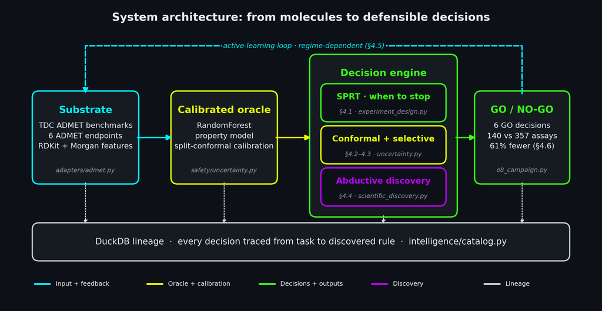

```python
"""Display Figure 0: the RandomForest decision-engine schematic (fig0_architecture.png)."""
show_fig("fig0_architecture.png", width=1100)
```

<sub>**Figure 0.** System architecture of the CPU-reproducible sequential campaign. Molecular descriptors feed a RandomForest property oracle with split-conformal calibration; the decision engine combines sequential stopping, conformal uncertainty and selective prediction, and abductive discovery to make traceable go/no-go calls. Blue denotes inputs and feedback, neon yellow the oracle and calibration, green decisions and outputs, purple discovery, and grey DuckDB lineage. Module labels (for example "§4.1 · experiment_design.py") cite the section in which each component is evaluated and the source module that implements it.</sub>

## 4.1 Sequential decision efficiency (SPRT): knowing when to stop

The first decision is the most expensive one to get wrong: *how many molecules do we measure before committing to a go or no-go call?* Measure too few and the call is noise; measure too many and we have burned assay budget confirming something we already knew. Wald's sequential probability ratio test lets the data decide when enough is enough.

**Model.** Standardized per-measurement signals $x_i \sim \mathcal{N}(\theta,\sigma^2)$ with known $\sigma$. We test $H_0:\theta=\theta_0$ against $H_1:\theta=\theta_1$ ($\theta_1>\theta_0$), where $\theta_1-\theta_0$ is the a-priori "meaningful effect". After each measurement we form the per-sample log-likelihood ratio

$$ z_i = \log\frac{f_{\theta_1}(x_i)}{f_{\theta_0}(x_i)} = \frac{\theta_1-\theta_0}{\sigma^2}\Big(x_i-\frac{\theta_0+\theta_1}{2}\Big), $$

and accumulate $\Lambda_n=\sum_{i\le n} z_i$. We keep measuring while $\Lambda_n$ sits between Wald's boundaries $A=\log\frac{1-\beta}{\alpha}$ and $B=\log\frac{\beta}{1-\alpha}$, accept $H_1$ once $\Lambda_n\ge A$, and accept $H_0$ once $\Lambda_n\le B$. Wald's inequalities bound the realized error rates, $\alpha'\le\alpha/(1-\beta)$ and $\beta'\le\beta/(1-\alpha)$, with $\alpha'+\beta'\le\alpha+\beta$; because the random walk overshoots the boundary rather than landing on it, realized rates are typically below nominal. Wald & Wolfowitz (1948) showed that among all tests with error rates no larger than $(\alpha,\beta)$ the SPRT minimizes the expected sample size under both hypotheses. The comparator is the one-sided fixed-sample $z$-test, which needs $n_{\text{fix}}=\big((z_{1-\alpha}+z_{1-\beta})/\delta\big)^2$ measurements at standardized effect $\delta=(\theta_1-\theta_0)/\sigma$.

**Operating point.** The manuscript's headline (65 versus 99) is evaluated at the *empirical operating point*: the standardized mean shift of the top-tercile aromatic-ring-count subgroup in the TDC Lipophilicity_AstraZeneca set, 0.248 sigma, taken at the nearest sweep point, 0.25 sigma. The live cell below instead uses $\theta_1=0.30$ sigma, the a-priori meaningful effect that the autonomous campaign in Section 4.6 tests, so that the two sections share one question. The implementation is `intelligence/experiment_design.py::SPRT`.

```python
"""
Live SPRT operating characteristics by Monte Carlo simulation.

Methodology: operating characteristics of a sequential test have no closed form,
so we estimate them the standard way, by Monte Carlo under the test's own Gaussian
model. With the effect truly present (H1 true, mean = theta1) we run the SPRT to its
stopping boundary many times and average the stopping sample size to get the
realized average sample number and realized power; with no effect (H0 true) we
repeat the exercise to get the realized Type I error. We compare the H1 average
to the classical fixed-sample size n_fix required for the same alpha and beta.
The takeaway: the sequential test reaches a decision at matched nominal error
rates using materially fewer measurements.
"""
from scipy.stats import norm
from src.intelligence.experiment_design import SPRT

alpha, beta, sigma = 0.05, 0.20, 1.0
theta1 = 0.30  # a-priori meaningful effect in sigma units, matching the campaign question

def run_sprt(true_mean, seed):
    """Run one SPRT to its boundary; return (decision, stopping n, LLR path)."""
    rng = np.random.default_rng(seed)
    s = SPRT(theta_0=0.0, theta_1=theta1, alpha=alpha, beta=beta, sigma=sigma)
    path = []
    for _ in range(5000):                       # generous cap; the test stops far sooner
        d = s.update(float(rng.normal(true_mean, sigma)))
        path.append(s.log_likelihood_ratio)
        if d != "continue":
            break
    return s.decision, s.n_observations, np.array(path)

# Realized operating characteristics across 400 independent runs with the effect present (H1).
ns, correct = [], 0
for seed in range(400):
    d, n, _ = run_sprt(theta1, seed)
    ns.append(n); correct += (d == "reject_h0")     # a correct call rejects H0 when H1 is true
mean_n, power = float(np.mean(ns)), correct / 400
n_fix = ((norm.ppf(1 - alpha) + norm.ppf(1 - beta)) / theta1) ** 2   # classical fixed-sample size

# Realized Type I error across 400 runs with no effect (H0 true, mean = theta0 = 0).
false_go, ns0 = 0, []
for seed in range(400):
    d0, n0, _ = run_sprt(0.0, 10_000 + seed)
    false_go += (d0 == "reject_h0"); ns0.append(n0)
type1 = false_go / 400

print(f"SPRT mean N (H1 true) = {mean_n:.1f}   fixed-sample N = {n_fix:.1f}   "
      f"saving = {100 * (n_fix - mean_n) / n_fix:.0f}%")
print(f"realized power = {power:.2f}  (nominal 1 - beta = {1 - beta:.2f})     "
      f"realized Type I = {type1:.3f}  (nominal alpha = {alpha:.2f}; Wald bound alpha/(1-beta) = {alpha/(1-beta):.3f})")
print(f"SPRT mean N (H0 true) = {np.mean(ns0):.1f}")
```

```
SPRT mean N (H1 true) = 47.0   fixed-sample N = 68.7   saving = 32%
realized power = 0.83  (nominal 1 - beta = 0.80)     realized Type I = 0.045  (nominal alpha = 0.05; Wald bound alpha/(1-beta) = 0.062)
SPRT mean N (H0 true) = 34.9
```

**Reading the numbers.** At $\theta_1=0.30$ sigma the fixed-sample design needs 68.7 measurements; the SPRT averages about 47 when the effect is present, a saving near a third, with realized power close to the nominal 0.80 and realized Type I error below the nominal 0.05 (and well inside Wald's bound of 0.0625). Under $H_0$ the SPRT stops even sooner, because accepting $H_0$ requires crossing the nearer boundary $B$. The manuscript's headline figures (65 versus 98.9 at 0.25 sigma, 34%; 23% mean saving, power 0.85 and Type I 0.043 averaged over a 0.15-0.90 sigma sweep) come from the same procedure run over a grid of effect sizes; the live result here is one point on that curve at a slightly larger effect, so its absolute sample sizes are smaller and its relative saving is similar. One decision path makes the stopping rule concrete.

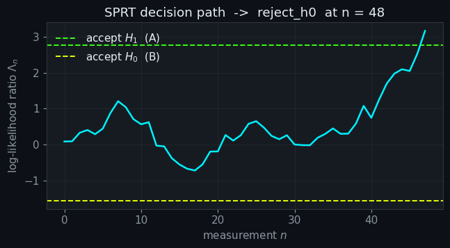

```python
"""
Visualize a single SPRT decision path.

Intent: make the stopping rule tangible. We plot the accumulated log-likelihood
ratio Lambda_n as measurements arrive and draw Wald's two boundaries. The walk
continues until it first crosses a boundary, which is the moment the engine
stops measuring and commits to a call.
"""
# one decision path walking between the Wald boundaries
d, n, path = run_sprt(theta1, 0)
A = np.log((1 - beta) / alpha)      # upper boundary: accept H1
B = np.log(beta / (1 - alpha))      # lower boundary: accept H0
fig, ax = plt.subplots(figsize=(6.6, 3.7))
ax.axhline(A, color=ACCENT_GREEN, ls="--", lw=1.4, label="accept $H_1$  (A)")
ax.axhline(B, color=ACCENT_ORANGE, ls="--", lw=1.4, label="accept $H_0$  (B)")
ax.plot(path, color=ACCENT_BLUE, lw=1.8)
ax.set_xlabel("measurement $n$")
ax.set_ylabel(r"log-likelihood ratio $\Lambda_n$")
ax.set_title(f"SPRT decision path  ->  {d}  at n = {n}")
ax.legend(frameon=False, facecolor=CARD_BG, edgecolor=BORDER, labelcolor=TEXT_PRIMARY)
plt.tight_layout(); plt.show()
```

The single path above is one draw. The full picture is the effect-size sweep: for every effect size we compare the SPRT's average sample number against the fixed-sample requirement, with the empirical operating point annotated.

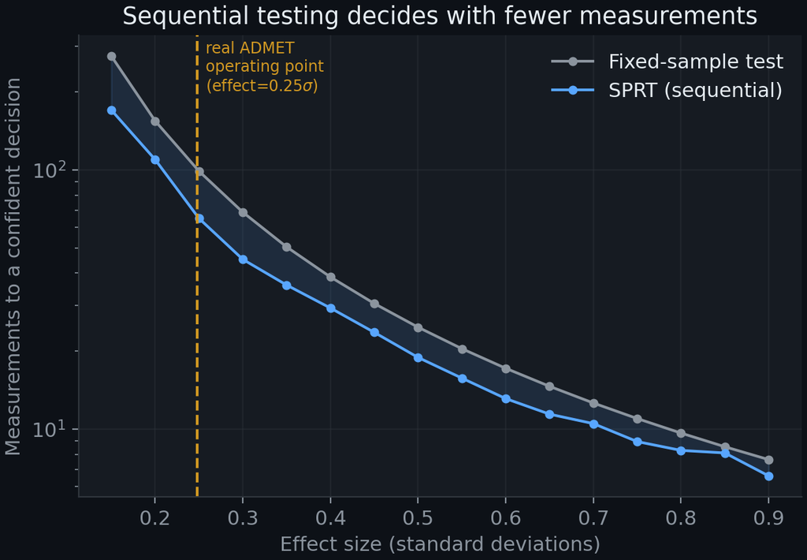

```python
"""Show the committed effect-size sweep, Figure 1 (fig1_sprt_efficiency.png)."""
show_fig("fig1_sprt_efficiency.png")
```

<sub>**Figure 1.** Sequential probability ratio test versus a one-sided fixed-sample *z*-test at matched nominal α=0.05, β=0.20. The curves are the average sample number to a decision over 300 simulated runs per effect size; the shaded band is the saving. At the empirical operating point (dashed line, 0.25σ; the lipophilicity high-aromatic subgroup shift) SPRT needs 65 versus 99 measurements. Realized error rates across the sweep: power 0.85, Type I 0.043.</sub>

**Result.** SPRT reaches a decision using fewer measurements on average at every effect size in the sweep. At the empirical operating point it needs **65.0 versus 98.9** measurements, a **34%** saving; the mean saving across effect sizes is **23%**. The saving is largest in relative terms at small effects, exactly where measurement budgets hurt most. Two caveats carry through the rest of the document: the model is Gaussian with known $\sigma$ (estimated from the pool), and the operating characteristics we quote are the ones the procedure actually realizes, measured by Monte Carlo, with Wald's asymptotic bound serving only as an upper limit.

## 4.2 Calibrated coverage under scaffold shift: knowing what you do not know

A point prediction with no honest uncertainty cannot be acted on, least of all when a program moves into chemical scaffolds it has never seen. The second decision is about *trust*: how closely does coverage on held-out scaffolds approach its nominal target?

**Split conformal.** With nonconformity score $s(x,y)=1-\hat p_y(x)$ (one minus the model's probability on the true label) and calibration scores $s_1,\dots,s_n$, let $\hat q$ be the $\lceil(n+1)(1-\alpha)\rceil$-th smallest, and predict the set $C(x)=\{y: 1-\hat p_y(x)\le \hat q\}$. If the calibration and test scores are exchangeable, the rank of the test score among the $n+1$ is uniform, so

$$ P\big(Y_{n+1}\in C(X_{n+1})\big)\ge \frac{\lceil (n+1)(1-\alpha)\rceil}{n+1}\ge 1-\alpha, $$

distribution-free (Vovk et al. 2005; Angelopoulos & Bates 2023). **A scaffold-cold split deliberately breaks exchangeability**: whole Murcko scaffolds (Bemis & Murcko 1996) are reserved for test, so calibration molecules and test molecules are drawn from different chemistry. Evaluating on held-out scaffolds therefore *measures* coverage under shift; it does not guarantee it, and we do not apply shift-weighted conformal methods (Tibshirani et al. 2019). The implementation is `safety/uncertainty.py::calibrate_conformal`. The cell below recomputes coverage live on the real held-out BBB, hERG, and AMES predicted probabilities shipped with the repository, reproducing the manuscript's numbers exactly.

```python
"""
Live split-conformal coverage on real held-out ADMET predictions.

Methodology: load the committed real predicted probabilities and labels for the
three benchmarks (BBB, hERG, AMES), each split so that calibration and test share
no molecular scaffold. For each task we compute the conformal threshold q on the
calibration set at alpha = 0.10, then measure how often the true label falls inside
the predicted set on the held-out scaffolds. These are the numbers reported in the
manuscript, recomputed here from the committed artifact
preprint/conformal_selective_real.npz (real TDC data; no download, no retraining).
"""
from src.safety.uncertainty import UncertaintyQuantifier

A = np.load(PRE / "conformal_selective_real.npz")
alpha = 0.10

def conformal_coverage(cal_probs, cal_y, test_probs, test_y):
    uq = UncertaintyQuantifier(alpha=alpha)
    q = uq.calibrate_conformal(cal_probs, cal_y)   # threshold from calibration scores
    scores = 1.0 - test_probs                       # test nonconformity s = 1 - p_true
    inset = [lab in np.where(scores[i] <= q)[0] for i, lab in enumerate(test_y)]
    return float(np.mean(inset))

print(f"target coverage {1 - alpha:.2f}   (empirical coverage on held-out sets)")
print(f"{'task':6s} {'random':>8s} {'scaffold':>10s}")
for t in ["BBB", "hERG", "AMES"]:
    cov_rand = conformal_coverage(A[f"{t}_cal_probs_rand"], A[f"{t}_cal_y_rand"],
                                  A[f"{t}_test_probs_rand"], A[f"{t}_test_y_rand"])
    cov_scaf = conformal_coverage(A[f"{t}_cal_probs_scaf"], A[f"{t}_cal_y_scaf"],
                                  A[f"{t}_test_probs_scaf"], A[f"{t}_test_y_scaf"])
    print(f"{t:6s} {cov_rand:8.3f} {cov_scaf:10.3f}")
```

```
target coverage 0.90   (empirical coverage on held-out sets)
task     random   scaffold
BBB       0.878      0.884
hERG      0.909      0.869
AMES      0.897      0.899
```

**Result.** Under scaffold shift, empirical coverage at $\alpha=0.10$ is **BBB 0.884, hERG 0.869, AMES 0.899** against the nominal 0.90; BBB and hERG fall below it, by 1.6 and 3.1 points. The random-split values are 0.878, 0.909, and 0.897. The shortfall is small but real, and it is the honest reading of a guarantee that was never promised under shift. Probability calibration of the BBB oracle on the random split is good: expected calibration error is **0.044** over ten equal-width bins.

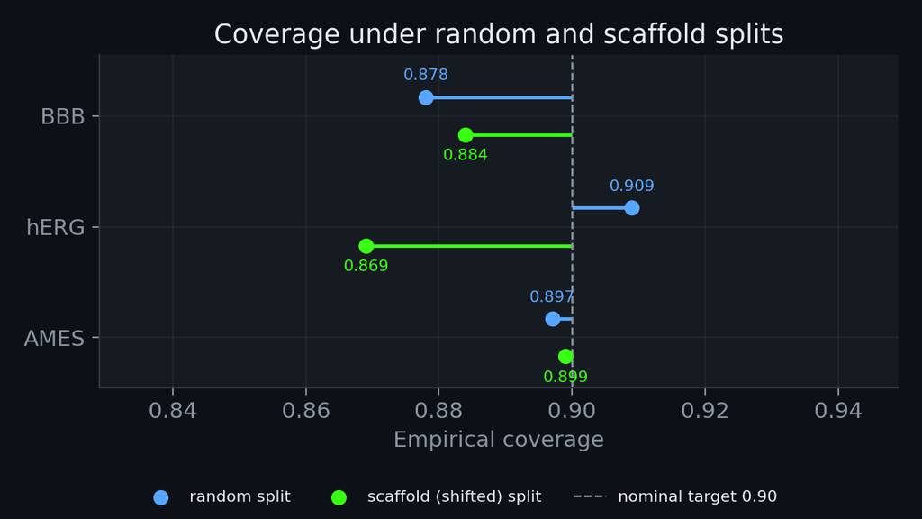

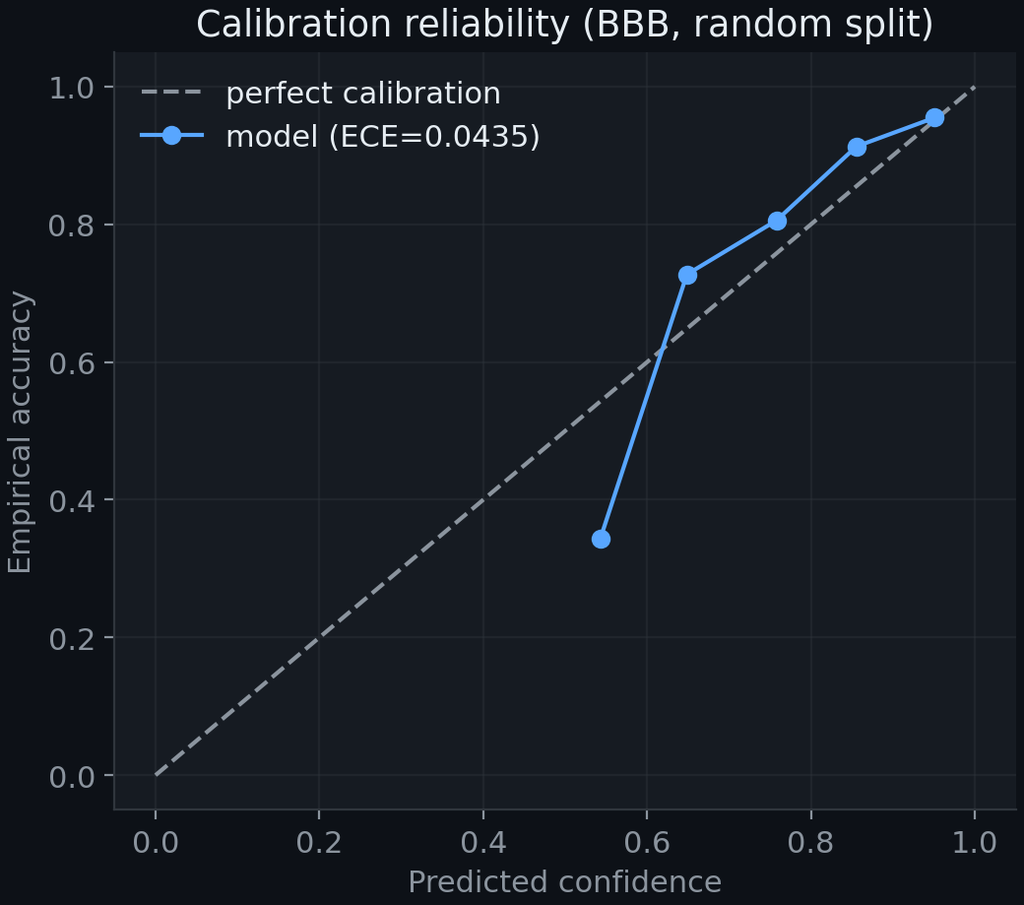

```python
"""Show the committed coverage and reliability figures, Figures 2 and 3 (fig2_conformal_coverage.png, fig3_calibration_reliability.png)."""
show_fig("fig2_conformal_coverage.png", "fig3_calibration_reliability.png")
```

<sub>**Figure 2.** Empirical split-conformal coverage under random and scaffold-cold splits for BBB, hERG and AMES. Scaffold coverage is 0.884 (BBB), 0.869 (hERG), and 0.899 (AMES); the dashed line marks the nominal 0.90 target, which is a finite-sample guarantee only under exchangeability and so is not guaranteed under shift. Each stem shows the gap to the target.</sub>

<sub>**Figure 3.** BBB random-split reliability diagram. Expected calibration error is 0.0435 over ten equal-width confidence bins; only the five bins above 0.5 are populated because the confidence score is the maximum class probability of a binary classifier. The four upper bins sit close to the diagonal (slightly under-confident); the lowest populated bin (confidence about 0.54, accuracy about 0.34) is over-confident, but holds few molecules and so contributes little to the ECE.</sub>

## 4.3 Selective prediction: knowing when to abstain

Coverage tells us whether the uncertainty is honest; selective prediction turns that honesty into an action. The third decision is simply to **decline to answer** on the cases the engine is least sure about, handing those to a human or a more expensive assay.

Abstain when the confidence $g(x)=\max_y\hat p_y(x)$ falls below a threshold $\tau$. Define coverage $\phi(\tau)=P(g(X)\ge\tau)$ and selective risk $R(\tau)=E[\ell(\hat f(X),Y)\mid g(X)\ge\tau]$. If $g$ ranks points by their true probability of correctness, $R(\tau)$ is non-increasing as coverage falls: the monotone risk-coverage trade-off (El-Yaniv & Wiener 2010; Geifman & El-Yaniv 2017). The practical test is whether abstaining on the least-confident 30% removes a disproportionate share of the errors, which requires only that $g$ rank errors better than chance. The cell below recomputes retained accuracy at 70% coverage from the real held-out BBB predictions for both random and scaffold splits; Figure 4 shows the full risk-coverage curve.

```python
"""
Live selective-accuracy check on real held-out BBB predictions.

Intent: using the committed real predicted probabilities for the BBB benchmark,
sort molecules from most to least confident and sweep the retained fraction
(coverage). At each coverage we keep only the most-confident molecules and measure
their accuracy. Accuracy rising as coverage falls is the signature of a confidence
score that ranks errors better than chance. The committed Figure 4 below shows
the full curve, so this cell prints only the two headline points.
"""
A = np.load(PRE / "conformal_selective_real.npz")

def risk_coverage(probs, labels):
    conf = probs.max(1); order = np.argsort(-conf)   # most-confident first
    yl, yp = labels[order], probs.argmax(1)[order]
    covs = np.linspace(0.1, 1.0, 19)                  # retained fractions to sweep
    accs = [float(np.mean(yl[:max(1, int(c * len(yl)))] == yp[:max(1, int(c * len(yl)))]))
            for c in covs]
    return covs, np.array(accs)

cr, ar = risk_coverage(A["SEL_test_probs_rand"], A["SEL_test_y_rand"])
cs, asf = risk_coverage(A["SEL_test_probs_scaf"], A["SEL_test_y_scaf"])
print(f"base accuracy at full coverage: {ar[-1]:.3f}")
print(f"accuracy at 70% coverage: random {np.interp(0.7, cr, ar):.3f}   "
      f"scaffold {np.interp(0.7, cs, asf):.3f}")
```

```
base accuracy at full coverage: 0.864
accuracy at 70% coverage: random 0.944   scaffold 0.939
```

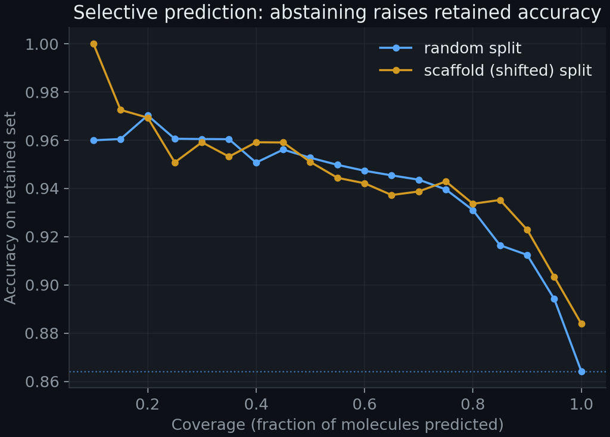

```python
"""Show the committed selective-prediction figure, Figure 4 (fig4_selective_prediction.png)."""
show_fig("fig4_selective_prediction.png")
```

<sub>**Figure 4.** Risk-coverage trade-off for the BBB oracle. Molecules are ranked by maximum class probability and the most-confident fraction (coverage) is retained. Retained accuracy rises from the full-coverage base (dotted line, 0.864 random split) to 0.94 at 70% coverage under both random and scaffold splits; the two curves track each other, so the confidence ranking survives scaffold shift even though coverage does not perfectly.</sub>

**Result.** Abstaining on the least-confident molecules raises retained accuracy to **0.94** at 70% coverage under both splits, from a random-split base of **0.864** (the scaffold split starts slightly higher, near 0.884, and reaches the same level). That the scaffold curve is not worse than the random curve is the useful finding: the oracle's confidence *ranking* transfers across scaffold shift even when its conformal coverage falls a little short. At very low coverage the curves become noisy because few molecules remain.

## 4.4 Autonomous, interpretable discovery

Cheap, calibrated decisions are only half the promise; the engine should also *learn something we can read*. The abductive discovery cycle (`intelligence/scientific_discovery.py::run_discovery_cycle`) works per endpoint: it fits a descriptor meta-model, flags surprises (|z| > 2 residuals), distills a one-split regression tree on z-scored descriptors, and checks the split feature (and the top Spearman correlate) against the established structure-property driver. On the two regression endpoints it also enumerates structure-property cliffs: molecule pairs with high Morgan-fingerprint Tanimoto similarity (0.70-0.99) and a large property gap (|ΔY| ≥ 2), the structure-activity landscape index of Guha & Van Drie (2008). Across the five probed endpoints it recovers the known driver on 5 of 5 and surfaces 1398 cliffs. The numbers below load straight from the committed results.

```
Abductive rule rediscovery:
  bbb            driver = TPSA     meta-R2 = 0.30   recovered = True
  solubility     driver = MolLogP  meta-R2 = 0.49   recovered = True
  hia            driver = TPSA     meta-R2 = 0.37   recovered = True
  caco2          driver = HBD      meta-R2 = 0.55   recovered = True
  lipophilicity  driver = MolLogP  meta-R2 = 0.26   recovered = True

structure-property cliffs surfaced: 1398  (lipophilicity 152, solubility 1246)
```

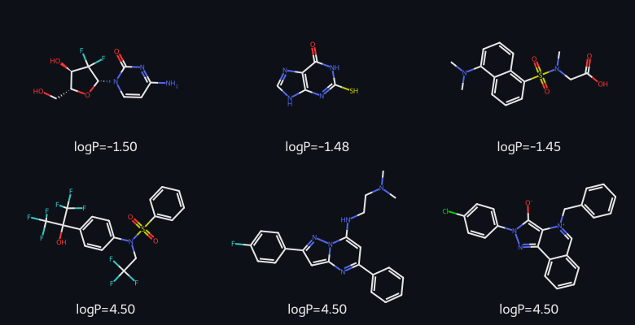

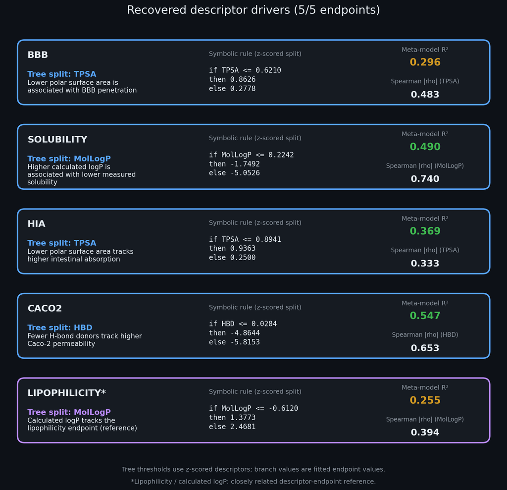

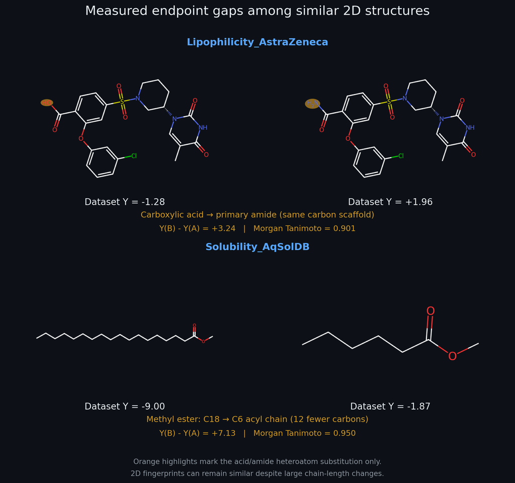

```python
"""
Summarize the abductive rediscovery results.

Intent: for each endpoint, print the distilled single-feature driver, its
meta-model R-squared, and whether it matches the established structure-property
relationship. Then total the surfaced property cliffs by endpoint and show the
lipophilicity endpoint extremes (Figure 5), the rule cards (Figure 6) and the
cliff panel (Figure 7).
"""
res = json.load(open(PRE / "e7_discovery_results.json"))
print("Abductive rule rediscovery:")
for r in res["rediscovery"]:
    print(f"  {r['endpoint']:14s} driver = {r['tree_feature']:8s} "
          f"meta-R2 = {r['meta_r2']:.2f}   recovered = {r['driver_hit']}")
n_cliffs = sum(b["n_cliffs"] for b in res["cliffs"])   # totals to the 1398 reported
per_ep = ", ".join(f"{b['endpoint']} {b['n_cliffs']}" for b in res["cliffs"])
print(f"\nstructure-property cliffs surfaced: {n_cliffs}  ({per_ep})")
show_fig("fig5_molecules.png", width=700)
show_fig("fig6_rule_cards.png", "fig7_cliff_panel.png")
```

<sub>**Figure 5.** Illustrative structures at the three lowest and three highest observed values in the TDC Lipophilicity_AstraZeneca set. The endpoint is the experimental octanol/water distribution coefficient at pH 7.4 (logD<sub>7.4</sub>), labelled logP in the panel for brevity. These are endpoint extremes, not matched activity-cliff pairs; polar, ionizable or heavily hydrogen-bonding structures sit at the bottom and lipophilic aryl systems at the top.</sub>

<sub>**Figure 6.** Recovered descriptor-rule cards, one per probed endpoint. Each row gives the one-split tree rule on the z-scored descriptor (threshold in standard-deviation units, branch values in endpoint units), the meta-model R<sup>2</sup>, and the absolute Spearman correlation of the split feature with the endpoint. Branch values show the direction of each association: lower TPSA → higher BBB penetration and HIA, higher calculated logP → lower aqueous solubility, fewer H-bond donors → higher Caco-2 permeability. The lipophilicity calculated-logP pairing (purple) is a closely related descriptor-endpoint reference, not an independent driver discovery.</sub>

<sub>**Figure 7.** Two observed property contrasts among similar 2D structures. Top: a carboxylic acid and its primary amide on a shared scaffold (lipophilicity Y −1.28 vs +1.96; Morgan Tanimoto 0.901); because the endpoint is logD at pH 7.4, the ionized acid is far more hydrophilic than the neutral amide, so the gap is chemically expected. Bottom: C18 versus C6 methyl esters (solubility Y −9.00 vs −1.87 log mol/L; Tanimoto 0.950), where a twelve-carbon chain-length change barely moves a circular fingerprint but changes solubility by seven log units. These are measured associations that illustrate what a fingerprint-similarity cliff does and does not capture, not causal effects.</sub>

**Result.** The recovered pairings are BBB → TPSA (meta-R<sup>2</sup> 0.30), solubility → calculated logP (0.49), HIA → TPSA (0.37), Caco2 → HBD (0.55), and lipophilicity → calculated logP (0.26). The last is counted as a closely related descriptor-endpoint reference rather than an independent discovery, since calculated logP is itself an estimate of the measured quantity: **four independent drivers plus one reference, 5 of 5 probed**. The 1398 cliffs come from the two regression endpoints (1246 on solubility, 152 on lipophilicity); the classification endpoints have no continuous gap to rank. Meta-model R<sup>2</sup> values of 0.26-0.55 are modest by design: a single descriptor split is meant to be *readable*, not to be the oracle.

## 4.5 The value of active learning is regime-dependent

It is tempting to claim that uncertainty-driven data acquisition always beats picking molecules at random. Our hardening experiments say otherwise, and we report the honest version. Setup: a K=3 deep-ensemble graph-neural-network oracle on scaffold-cold splits, 120 seed labels then 18 rounds of 120 labels acquired either by ensemble predictive variance (query-by-committee) or at random, 3 seeds, and a 2000-resample bootstrap CI on the paired per-seed gap in area under the held-out-R<sup>2</sup> learning curve (AULC). Uncertainty-driven acquisition beat random **only when the passive baseline was unstable** (solubility: mean paired AULC gap +0.276, bootstrap CI [−0.102, +0.445], not significant at n=3 seeds), and was significantly *negative* when the baseline was already stable (lipophilicity: gap −0.026, CI [−0.070, −0.022]). So we treat active learning as a characterized, regime-dependent decision rule and make no claim of a universal advantage (Settles 2012; Frazier 2018). The figure is drawn from the committed deep-ensemble curves (`g1_harden_curves.npz`), which were trained on GPU; plotting them needs no GPU.

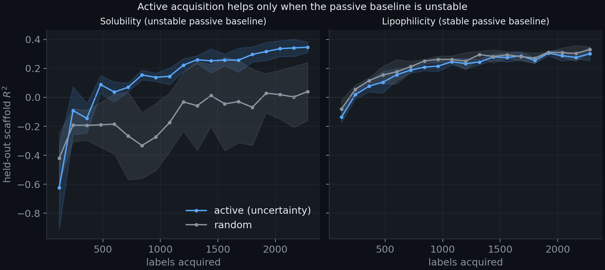

```python
"""Show the committed regime-dependent label-efficiency figure, Figure 8 (fig8_label_efficiency_regime.png)."""
show_fig("fig8_label_efficiency_regime.png", width=1200)
```

<sub>**Figure 8.** Label-efficiency curves (held-out scaffold R<sup>2</sup> versus labels acquired; mean and seed range over 3 seeds). Left, solubility: the random baseline is unstable (wide band, negative R<sup>2</sup> for most of the run) and uncertainty-driven acquisition climbs steadily above it, but the 3-seed bootstrap CI on the gap includes zero. Right, lipophilicity: the random baseline is stable and the active curve sits slightly but significantly below it. The benefit of active acquisition is regime-dependent.</sub>

**What this does and does not say.** Two endpoints and three seeds cannot support a general law; what they do support is a rule the engine can act on: run uncertainty-driven acquisition when a cheap passive pilot is unstable, and do not pay for it when the passive baseline is already learning smoothly. Note also that the acquisition score here is the deep-ensemble oracle's own predictive variance; the Gaussian-process surrogate the wider codebase provides for Bayesian optimization is a separate acquisition path.

## 4.6 End-to-end autonomous campaign

Finally we wire the pieces into one closed loop and let it run unattended over six ADMET endpoints (BBB, AMES, hERG, solubility, Caco2, HIA). For each endpoint the engine trains a calibrated RandomForest oracle on a leakage-controlled scaffold-cold split, poses an a-priori go/no-go question (*is the oracle's top-predicted 30% of held-out novel-scaffold molecules shifted from the pool baseline by at least 0.3 sigma?*), measures that subgroup one molecule at a time in random order, stops via SPRT ($\alpha=0.05$, $\beta=0.20$), distills an abductive rule, and logs every step to a DuckDB lineage store. The result is a campaign whose every decision is traceable from the task all the way to the discovered rule.

**Two protocol details matter for reading the result.** First, the direction of the alternative is set from the realized sign of the subgroup mean, so the test is a two-sided screen run at nominal $\alpha$ per side; the realized Type I error is bounded by $2\alpha$, not $\alpha$, and a pre-registered direction would restore the one-sided rate. Second, the fixed-sample comparator is capped at the size of the available subgroup, because a fixed design could not measure more molecules than exist (hERG 49, HIA 33; the other four endpoints use the uncapped 68.7).

```
E8 campaign: 6 GO / 0 NO-GO across 6 endpoints
measurements used 140 vs fixed 357  ->  61% saved

  bbb          GO (meaningful shift)      effect +0.43sigma   used  38 vs  68.7   rule = TPSA
  ames         GO (meaningful shift)      effect +0.62sigma   used  24 vs  68.7   rule = ArRings
  herg         GO (meaningful shift)      effect +0.58sigma   used  18 vs  49.0   rule = HeavyAtoms
  solubility   GO (meaningful shift)      effect +0.79sigma   used  10 vs  68.7   rule = MolLogP
  caco2        GO (meaningful shift)      effect +0.70sigma   used  17 vs  68.7   rule = HBD
  hia          GO (meaningful shift)      effect +0.43sigma   used  33 vs  33.0   rule = TPSA
```

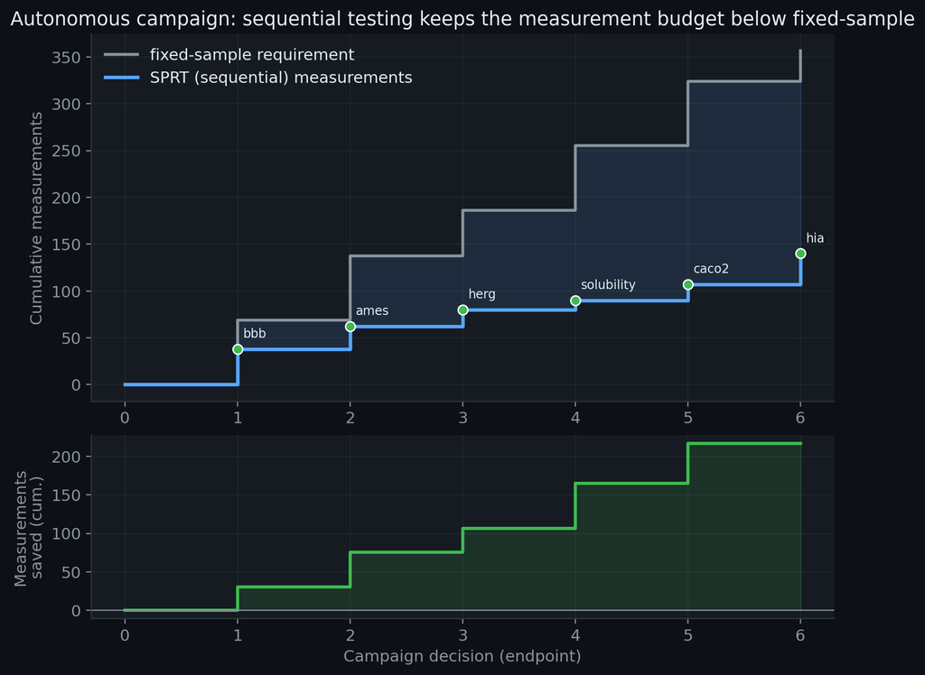

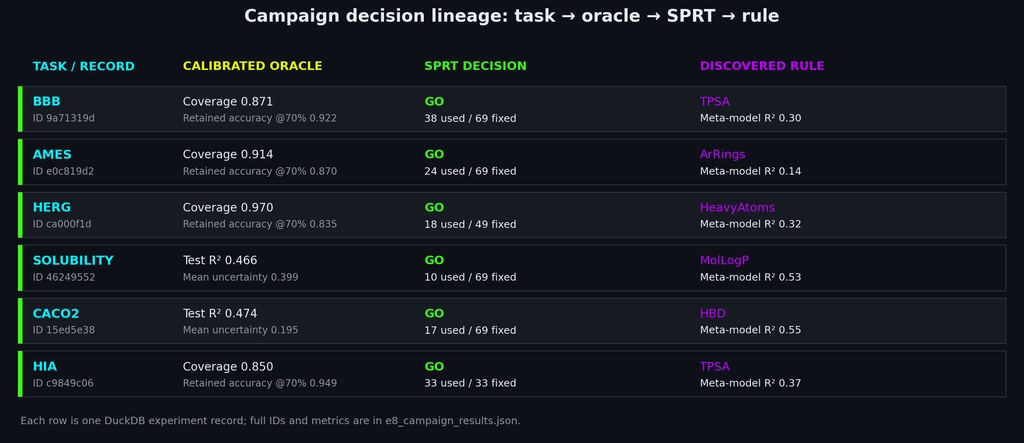

```python
"""
Summarize the end-to-end autonomous campaign.

Intent: load the committed campaign roll-up and print, per endpoint, the SPRT
verdict, the observed subgroup shift, the measurements it used versus the
(subgroup-capped) fixed-sample requirement, and the rule it distilled. The header line reports the campaign-wide budget saving; the
figures show the timeline and the task-to-rule lineage graph.
"""
camp = json.load(open(PRE / "e8_campaign_results.json"))
print(f"E8 campaign: {camp['decisions_go']} GO / {camp['decisions_nogo']} NO-GO "
      f"across {camp['n_endpoints']} endpoints")
print(f"measurements used {camp['total_measurements_used']} vs fixed "
      f"{camp['total_fixed_sample']:.0f}  ->  {camp['fraction_saved'] * 100:.0f}% saved\n")
for r in camp["records"]:
    s = r["sprt"]
    print(f"  {r['endpoint']:12s} {s['verdict']:26s} effect {s['effect_observed']:+.2f}sigma   "
          f"used {s['n_measurements']:3d} vs {s['fixed_sample_n']:5.1f}   rule = {r['rule']['tree_feature']}")
show_fig("fig9_campaign_timeline.png", width=1100)   # Figure 9
show_fig("fig10_lineage_graph.png", width=1600)      # Figure 10
```

<sub>**Figure 9.** End-to-end autonomous campaign timeline. Top: cumulative measurements as the six decisions are made in order (BBB, AMES, hERG, solubility, Caco2, HIA); the SPRT path (blue) stays at or below the fixed-sample requirement (grey), with the fixed-sample step for hERG and HIA capped at the available subgroup size. Bottom: the running measurements-saved counter, ending at 217 of 357 (61%). The HIA step adds nothing because SPRT used the whole subgroup.</sub>

<sub>**Figure 10.** Campaign lineage matrix. Each row connects an endpoint and DuckDB record ID to its oracle check (conformal coverage and retained accuracy at 70% coverage for classification endpoints; test R<sup>2</sup> and mean predictive uncertainty for regression endpoints), its SPRT decision and measurement budget, and the discovered one-split rule with its meta-model R<sup>2</sup>. Coverage ranges from 0.85 (HIA) to 0.97 (hERG) at the 0.90 target.</sub>

**Result.** Across the campaign the engine reaches a decision in **140 measurements versus the 357** a fixed-sample design would require, a **61% saving**, returning **6 GO decisions**, each traced to its calibrated oracle and a recovered descriptor association (meta-R<sup>2</sup> 0.14-0.55): BBB → TPSA, AMES → aromatic-ring count, hERG → heavy-atom count, solubility → calculated logP, Caco2 → HBD, HIA → TPSA. Six GO verdicts and no NO-GO is the expected outcome when every oracle carries real signal, because the subgroup under test is the oracle's own top-ranked set; a NO-GO would have flagged an oracle that fails to separate its top predictions from the pool. For AMES and hERG, endpoints the discovery probe of Section 4.4 did not cover, the recovered split is a descriptor association rather than an established mechanistic driver. The savings are largest where the observed shift is large (solubility 0.79 sigma, 10 measurements; Caco2 0.70 sigma, 17) and smallest where it is modest (BBB 0.43 sigma, 38); for HIA (0.43 sigma) the SPRT reached its boundary only on the 33rd and final available molecule, so it matches the capped fixed-sample budget and saves nothing. The campaign oracles' conformal coverage spans 0.85 (HIA) to 0.97 (hERG), reflecting small scaffold-cold test sets. The raw provenance is in `e8_campaign_lineage.duckdb` and the roll-up in `e8_campaign_results.json`.

## Synopsis, limitations, and how to regenerate

**What was shown.** Treating molecular property discovery as a calibrated sequential decision problem yields an engine whose three decisions each hold up on real ADMET data under leakage-controlled evaluation, and which compose into a working closed loop.

- **When to stop (SPRT, 4.1).** Go/no-go calls at matched nominal error rates with fewer measurements: 65 versus 99 at the empirical 0.25 sigma operating point (34%), 23% on average across effect sizes, realized power 0.85 and Type I 0.043 across the sweep; 140 versus 357 (61%) across the six-endpoint campaign.
- **What you do not know (conformal, 4.2).** Scaffold-shift coverage of 0.884 / 0.869 / 0.899 against a 0.90 target: close, two of three below, and reported as a measured diagnostic because the finite-sample guarantee needs exchangeability that scaffold shift breaks. BBB random-split ECE 0.044.
- **When to abstain (selective prediction, 4.3).** Retained accuracy 0.864 → 0.94 at 70% coverage under both splits; the confidence ranking transfers across shift.
- **What you can read (abductive discovery, 4.4).** Textbook drivers recovered on 5 of 5 probed endpoints (four independent plus one closely related reference), with 1398 property cliffs on the two regression endpoints.
- **Active learning (4.5).** Uncertainty-driven acquisition helps when the passive baseline is unstable and costs accuracy when it is already stable: a conditional, regime-dependent decision rule with no evidence of a universal advantage.
- **Provenance (4.6).** Every campaign decision is logged to DuckDB and traceable from task to oracle to SPRT verdict to rule.

**What the evidence does not establish.**

- This is a retrospective simulation over public libraries; no wet-lab loop is closed, and no clinical or prospective claim is made.
- Conformal coverage under scaffold shift is measured, not guaranteed; shift-weighted conformal methods are not applied.
- The campaign's go/no-go test sets its direction from the realized subgroup mean and tests the oracle's own top-ranked subgroup, so its realized Type I error is bounded by $2\alpha$; the six GO calls certify that each oracle separates its top-ranked molecules from the pool, and stop short of validating any particular chemistry.
- The active-learning comparison rests on two regression endpoints and three seeds.
- SPRT assumes an approximately Gaussian per-measurement model with known $\sigma$, and the campaign draws measurements without replacement from a finite subgroup. Throughout, we report the realized, simulated operating characteristics; the asymptotic Wald bounds serve as upper limits only.
- Drift monitoring and substructure-level uncertainty attribution did not pass a cheap feasibility probe and are carried as open future work, with no claim attached.

**What would change the conclusions.** A pre-registered test direction (restoring one-sided $\alpha$); shift-weighted conformal calibration; a prospective loop in which the GO calls surfaced here are the first candidates measured; and a learned molecular representation swapped in for the RandomForest oracle, which the calibration-and-stopping layer accepts unchanged.

**CPU versus GPU.** Everything above runs on CPU. The only GPU work in the wider project was the deep-ensemble acquisition study of Section 4.5; its curves are committed as `g1_harden_curves.npz` and no headline number depends on them.

**Regenerate everything** from the real Therapeutics Data Commons benchmarks (Huang et al. 2021), with the interpreter pinned to 3.11.2 and `seed=20260905`:

```
make repro-spine       # Sections 4.1-4.5 probes, discovery cycle, rule cards (CPU, ~5 min)
make repro-campaign    # Section 4.6 end-to-end campaign, timeline, lineage (CPU, ~5 min)
make notebook          # re-execute this walkthrough in place
```

Figure files are numbered as in this document (Figures 0-10). `make repro-*` regenerates the source figures under `preprint/figures/`; the curated snapshots displayed here live in `preprint/figures/sequential_preprint/` and Figure 0 regenerates from `preprint/architecture_figure.py`.

#### Generative AI Disclosure

Some assertions and model development steps within this document were developed with reference to Generative AI tools (Copilot; 2026 version). AI assistance was used for clarifying concepts, validating code logic, identifying potential errors, and generating some code segments. All AI-generated material was independently reviewed, debugged, and validated for correctness before inclusion.

## References

1. Wald, A. (1945). Sequential tests of statistical hypotheses. *Annals of Mathematical Statistics*, 16(2), 117-186.
2. Chaloner, K. & Verdinelli, I. (1995). Bayesian experimental design: a review. *Statistical Science*, 10(3), 273-304.
3. Rainforth, T., Foster, A., Ivanova, D. R. & Bickford Smith, F. (2024). Modern Bayesian experimental design. *Statistical Science*, 39(1), 100-114.
4. Settles, B. (2012). *Active Learning*. Synthesis Lectures on AI and ML, Morgan & Claypool.
5. Vovk, V., Gammerman, A. & Shafer, G. (2005). *Algorithmic Learning in a Random World*. Springer.
6. Angelopoulos, A. N. & Bates, S. (2023). Conformal prediction: a gentle introduction. *Foundations and Trends in Machine Learning*, 16(4), 494-591.
7. Guo, C., Pleiss, G., Sun, Y. & Weinberger, K. Q. (2017). On calibration of modern neural networks. *ICML*.
8. Gal, Y. & Ghahramani, Z. (2016). Dropout as a Bayesian approximation: representing model uncertainty in deep learning. *ICML*.
9. Lakshminarayanan, B., Pritzel, A. & Blundell, C. (2017). Simple and scalable predictive uncertainty estimation using deep ensembles. *NeurIPS*.
10. El-Yaniv, R. & Wiener, Y. (2010). On the foundations of noise-free selective classification. *JMLR*, 11, 1605-1641.
11. Geifman, Y. & El-Yaniv, R. (2017). Selective classification for deep neural networks. *NeurIPS*.
12. Xu, K., Hu, W., Leskovec, J. & Jegelka, S. (2019). How powerful are graph neural networks? *ICLR*.
13. Velickovic, P., Cucurull, G., Casanova, A., Romero, A., Lio, P. & Bengio, Y. (2018). Graph attention networks. *ICLR*.
14. Huang, K., Fu, T., Gao, W., et al. (2021). Therapeutics Data Commons: machine learning datasets and tasks for drug discovery and development. *NeurIPS Datasets and Benchmarks*.
15. Bemis, G. W. & Murcko, M. A. (1996). The properties of known drugs. 1. Molecular frameworks. *Journal of Medicinal Chemistry*, 39(15), 2887-2893.
16. Guha, R. & Van Drie, J. H. (2008). Structure-activity landscape index: identifying and quantifying activity cliffs. *Journal of Chemical Information and Modeling*, 48(3), 646-658.
17. Wald, A. & Wolfowitz, J. (1948). Optimum character of the sequential probability ratio test. *Annals of Mathematical Statistics*, 19(3), 326-339.
18. Tibshirani, R. J., Foygel Barber, R., Candès, E. & Ramdas, A. (2019). Conformal prediction under covariate shift. *NeurIPS*.
19. Rogers, D. & Hahn, M. (2010). Extended-connectivity fingerprints. *Journal of Chemical Information and Modeling*, 50(5), 742-754.
20. Frazier, P. I. (2018). A tutorial on Bayesian optimization. *arXiv:1807.02811*.